# Risk Factor Analysis

## Outcome Variable

**Outcome Variable:** sstunted

## Predictor Variables

**Intervention Variable:** birthwt

**Adjustment Set:**

- arm
- sex
- W_mage
- meducyrs
- feducyrs
- hhwealth_quart
- vagbrth
- W_nrooms
- brthmon
- W_parity
- impfloor
- impsan
- safeh20
- delta_W_mage
- delta_meducyrs
- delta_feducyrs
- delta_hhwealth_quart
- delta_vagbrth
- delta_W_nrooms
- delta_brthmon
- delta_W_parity
- delta_impfloor
- delta_impsan
- delta_safeh20

## Stratifying Variables

The analysis was stratified on these variable(s):

- agecat
- studyid
- country

## Data Summary

| agecat | studyid | country | birthwt | sstunted | n_cell | n |
| --- | --- | --- | --- | --- | --- | --- |
| Birth | ki0047075b-MAL-ED | BANGLADESH | Normal or high birthweight | 0 | 201 | 257 |
| Birth | ki0047075b-MAL-ED | BANGLADESH | Normal or high birthweight | 1 | 1 | 257 |
| Birth | ki0047075b-MAL-ED | BANGLADESH | Low birth weight | 0 | 47 | 257 |
| Birth | ki0047075b-MAL-ED | BANGLADESH | Low birth weight | 1 | 8 | 257 |
| Birth | ki0047075b-MAL-ED | BRAZIL | Normal or high birthweight | 0 | 179 | 191 |
| Birth | ki0047075b-MAL-ED | BRAZIL | Normal or high birthweight | 1 | 4 | 191 |
| Birth | ki0047075b-MAL-ED | BRAZIL | Low birth weight | 0 | 4 | 191 |
| Birth | ki0047075b-MAL-ED | BRAZIL | Low birth weight | 1 | 4 | 191 |
| Birth | ki0047075b-MAL-ED | INDIA | Normal or high birthweight | 0 | 168 | 206 |
| Birth | ki0047075b-MAL-ED | INDIA | Normal or high birthweight | 1 | 4 | 206 |
| Birth | ki0047075b-MAL-ED | INDIA | Low birth weight | 0 | 31 | 206 |
| Birth | ki0047075b-MAL-ED | INDIA | Low birth weight | 1 | 3 | 206 |
| Birth | ki0047075b-MAL-ED | NEPAL | Normal or high birthweight | 0 | 154 | 173 |
| Birth | ki0047075b-MAL-ED | NEPAL | Normal or high birthweight | 1 | 1 | 173 |
| Birth | ki0047075b-MAL-ED | NEPAL | Low birth weight | 0 | 13 | 173 |
| Birth | ki0047075b-MAL-ED | NEPAL | Low birth weight | 1 | 5 | 173 |
| Birth | ki0047075b-MAL-ED | PERU | Normal or high birthweight | 0 | 267 | 287 |
| Birth | ki0047075b-MAL-ED | PERU | Normal or high birthweight | 1 | 2 | 287 |
| Birth | ki0047075b-MAL-ED | PERU | Low birth weight | 0 | 12 | 287 |
| Birth | ki0047075b-MAL-ED | PERU | Low birth weight | 1 | 6 | 287 |
| Birth | ki0047075b-MAL-ED | SOUTH AFRICA | Normal or high birthweight | 0 | 244 | 262 |
| Birth | ki0047075b-MAL-ED | SOUTH AFRICA | Normal or high birthweight | 1 | 0 | 262 |
| Birth | ki0047075b-MAL-ED | SOUTH AFRICA | Low birth weight | 0 | 16 | 262 |
| Birth | ki0047075b-MAL-ED | SOUTH AFRICA | Low birth weight | 1 | 2 | 262 |
| Birth | ki0047075b-MAL-ED | TANZANIA, UNITED REPUBLIC OF | Normal or high birthweight | 0 | 113 | 123 |
| Birth | ki0047075b-MAL-ED | TANZANIA, UNITED REPUBLIC OF | Normal or high birthweight | 1 | 3 | 123 |
| Birth | ki0047075b-MAL-ED | TANZANIA, UNITED REPUBLIC OF | Low birth weight | 0 | 4 | 123 |
| Birth | ki0047075b-MAL-ED | TANZANIA, UNITED REPUBLIC OF | Low birth weight | 1 | 3 | 123 |
| Birth | ki1000108-CMC-V-BCS-2002 | INDIA | Normal or high birthweight | 0 | 77 | 90 |
| Birth | ki1000108-CMC-V-BCS-2002 | INDIA | Normal or high birthweight | 1 | 3 | 90 |

[output cut: 286 more lines]

The following strata were considered:

- agecat: 24 months, studyid: ki0047075b-MAL-ED, country: BANGLADESH
- agecat: 24 months, studyid: ki0047075b-MAL-ED, country: BRAZIL
- agecat: 24 months, studyid: ki0047075b-MAL-ED, country: INDIA
- agecat: 24 months, studyid: ki0047075b-MAL-ED, country: NEPAL
- agecat: 24 months, studyid: ki0047075b-MAL-ED, country: PERU
- agecat: 24 months, studyid: ki0047075b-MAL-ED, country: SOUTH AFRICA
- agecat: 24 months, studyid: ki0047075b-MAL-ED, country: TANZANIA, UNITED REPUBLIC OF
- agecat: 24 months, studyid: ki1000108-CMC-V-BCS-2002, country: INDIA
- agecat: 24 months, studyid: ki1000108-IRC, country: INDIA
- agecat: 24 months, studyid: ki1017093-NIH-Birth, country: BANGLADESH
- agecat: 24 months, studyid: ki1017093b-PROVIDE, country: BANGLADESH
- agecat: 24 months, studyid: ki1017093c-NIH-Crypto, country: BANGLADESH
- agecat: 24 months, studyid: ki1066203-TanzaniaChild2, country: TANZANIA, UNITED REPUBLIC OF
- agecat: 24 months, studyid: ki1101329-Keneba, country: GAMBIA
- agecat: 24 months, studyid: ki1114097-CMIN, country: BANGLADESH
- agecat: 24 months, studyid: ki1114097-CMIN, country: PERU
- agecat: 24 months, studyid: ki1114097-CONTENT, country: PERU
- agecat: 24 months, studyid: ki1119695-PROBIT, country: BELARUS
- agecat: 24 months, studyid: ki1126311-ZVITAMBO, country: ZIMBABWE
- agecat: 24 months, studyid: ki1135781-COHORTS, country: GUATEMALA
- agecat: 24 months, studyid: ki1135781-COHORTS, country: INDIA
- agecat: 24 months, studyid: ki1135781-COHORTS, country: PHILIPPINES
- agecat: 24 months, studyid: kiGH5241-JiVitA-3, country: BANGLADESH
- agecat: 24 months, studyid: kiGH5241-JiVitA-4, country: BANGLADESH
- agecat: 6 months, studyid: ki0047075b-MAL-ED, country: BANGLADESH
- agecat: 6 months, studyid: ki0047075b-MAL-ED, country: BRAZIL
- agecat: 6 months, studyid: ki0047075b-MAL-ED, country: INDIA
- agecat: 6 months, studyid: ki0047075b-MAL-ED, country: NEPAL
- agecat: 6 months, studyid: ki0047075b-MAL-ED, country: PERU
- agecat: 6 months, studyid: ki0047075b-MAL-ED, country: SOUTH AFRICA
- agecat: 6 months, studyid: ki0047075b-MAL-ED, country: TANZANIA, UNITED REPUBLIC OF
- agecat: 6 months, studyid: ki1000108-CMC-V-BCS-2002, country: INDIA
- agecat: 6 months, studyid: ki1000108-IRC, country: INDIA
- agecat: 6 months, studyid: ki1000109-EE, country: PAKISTAN
- agecat: 6 months, studyid: ki1000109-ResPak, country: PAKISTAN
- agecat: 6 months, studyid: ki1000304b-SAS-CompFeed, country: INDIA
- agecat: 6 months, studyid: ki1017093-NIH-Birth, country: BANGLADESH
- agecat: 6 months, studyid: ki1017093b-PROVIDE, country: BANGLADESH
- agecat: 6 months, studyid: ki1017093c-NIH-Crypto, country: BANGLADESH
- agecat: 6 months, studyid: ki1066203-TanzaniaChild2, country: TANZANIA, UNITED REPUBLIC OF
- agecat: 6 months, studyid: ki1101329-Keneba, country: GAMBIA
- agecat: 6 months, studyid: ki1114097-CMIN, country: BANGLADESH
- agecat: 6 months, studyid: ki1114097-CMIN, country: BRAZIL
- agecat: 6 months, studyid: ki1114097-CMIN, country: GUINEA-BISSAU
- agecat: 6 months, studyid: ki1114097-CMIN, country: PERU
- agecat: 6 months, studyid: ki1114097-CONTENT, country: PERU
- agecat: 6 months, studyid: ki1119695-PROBIT, country: BELARUS
- agecat: 6 months, studyid: ki1126311-ZVITAMBO, country: ZIMBABWE
- agecat: 6 months, studyid: ki1135781-COHORTS, country: GUATEMALA
- agecat: 6 months, studyid: ki1135781-COHORTS, country: INDIA
- agecat: 6 months, studyid: ki1135781-COHORTS, country: PHILIPPINES
- agecat: 6 months, studyid: kiGH5241-JiVitA-3, country: BANGLADESH
- agecat: 6 months, studyid: kiGH5241-JiVitA-4, country: BANGLADESH
- agecat: Birth, studyid: ki0047075b-MAL-ED, country: BANGLADESH
- agecat: Birth, studyid: ki0047075b-MAL-ED, country: BRAZIL
- agecat: Birth, studyid: ki0047075b-MAL-ED, country: INDIA
- agecat: Birth, studyid: ki0047075b-MAL-ED, country: NEPAL
- agecat: Birth, studyid: ki0047075b-MAL-ED, country: PERU
- agecat: Birth, studyid: ki0047075b-MAL-ED, country: SOUTH AFRICA
- agecat: Birth, studyid: ki0047075b-MAL-ED, country: TANZANIA, UNITED REPUBLIC OF
- agecat: Birth, studyid: ki1000108-CMC-V-BCS-2002, country: INDIA
- agecat: Birth, studyid: ki1000108-IRC, country: INDIA
- agecat: Birth, studyid: ki1000109-EE, country: PAKISTAN
- agecat: Birth, studyid: ki1000109-ResPak, country: PAKISTAN
- agecat: Birth, studyid: ki1000304b-SAS-CompFeed, country: INDIA
- agecat: Birth, studyid: ki1017093-NIH-Birth, country: BANGLADESH
- agecat: Birth, studyid: ki1017093c-NIH-Crypto, country: BANGLADESH
- agecat: Birth, studyid: ki1101329-Keneba, country: GAMBIA
- agecat: Birth, studyid: ki1114097-CMIN, country: BANGLADESH
- agecat: Birth, studyid: ki1114097-CMIN, country: BRAZIL
- agecat: Birth, studyid: ki1114097-CMIN, country: PERU
- agecat: Birth, studyid: ki1114097-CONTENT, country: PERU
- agecat: Birth, studyid: ki1119695-PROBIT, country: BELARUS
- agecat: Birth, studyid: ki1126311-ZVITAMBO, country: ZIMBABWE
- agecat: Birth, studyid: ki1135781-COHORTS, country: GUATEMALA
- agecat: Birth, studyid: ki1135781-COHORTS, country: INDIA
- agecat: Birth, studyid: ki1135781-COHORTS, country: PHILIPPINES
- agecat: Birth, studyid: kiGH5241-JiVitA-3, country: BANGLADESH
- agecat: Birth, studyid: kiGH5241-JiVitA-4, country: BANGLADESH

### Dropped Strata

Some strata were dropped due to rare outcomes:

- agecat: Birth, studyid: ki0047075b-MAL-ED, country: BANGLADESH
- agecat: Birth, studyid: ki0047075b-MAL-ED, country: BRAZIL
- agecat: Birth, studyid: ki0047075b-MAL-ED, country: INDIA
- agecat: Birth, studyid: ki0047075b-MAL-ED, country: NEPAL
- agecat: Birth, studyid: ki0047075b-MAL-ED, country: PERU
- agecat: Birth, studyid: ki0047075b-MAL-ED, country: SOUTH AFRICA
- agecat: Birth, studyid: ki0047075b-MAL-ED, country: TANZANIA, UNITED REPUBLIC OF
- agecat: Birth, studyid: ki1000108-CMC-V-BCS-2002, country: INDIA
- agecat: Birth, studyid: ki1000109-EE, country: PAKISTAN
- agecat: Birth, studyid: ki1000109-ResPak, country: PAKISTAN
- agecat: Birth, studyid: ki1000304b-SAS-CompFeed, country: INDIA
- agecat: Birth, studyid: ki1017093-NIH-Birth, country: BANGLADESH
- agecat: Birth, studyid: ki1017093c-NIH-Crypto, country: BANGLADESH
- agecat: Birth, studyid: ki1114097-CMIN, country: BANGLADESH
- agecat: Birth, studyid: ki1114097-CMIN, country: BRAZIL
- agecat: Birth, studyid: ki1114097-CMIN, country: PERU
- agecat: Birth, studyid: ki1114097-CONTENT, country: PERU
- agecat: Birth, studyid: ki1119695-PROBIT, country: BELARUS
- agecat: Birth, studyid: ki1135781-COHORTS, country: GUATEMALA
- agecat: Birth, studyid: kiGH5241-JiVitA-4, country: BANGLADESH
- agecat: 6 months, studyid: ki0047075b-MAL-ED, country: BANGLADESH
- agecat: 6 months, studyid: ki0047075b-MAL-ED, country: BRAZIL
- agecat: 6 months, studyid: ki0047075b-MAL-ED, country: INDIA
- agecat: 6 months, studyid: ki0047075b-MAL-ED, country: NEPAL
- agecat: 6 months, studyid: ki0047075b-MAL-ED, country: SOUTH AFRICA
- agecat: 6 months, studyid: ki0047075b-MAL-ED, country: TANZANIA, UNITED REPUBLIC OF
- agecat: 6 months, studyid: ki1000109-ResPak, country: PAKISTAN
- agecat: 6 months, studyid: ki1017093-NIH-Birth, country: BANGLADESH
- agecat: 6 months, studyid: ki1017093b-PROVIDE, country: BANGLADESH
- agecat: 6 months, studyid: ki1066203-TanzaniaChild2, country: TANZANIA, UNITED REPUBLIC OF
- agecat: 6 months, studyid: ki1114097-CMIN, country: BANGLADESH
- agecat: 6 months, studyid: ki1114097-CMIN, country: BRAZIL
- agecat: 6 months, studyid: ki1114097-CMIN, country: GUINEA-BISSAU
- agecat: 6 months, studyid: ki1114097-CMIN, country: PERU
- agecat: 6 months, studyid: ki1114097-CONTENT, country: PERU
- agecat: 6 months, studyid: ki1119695-PROBIT, country: BELARUS
- agecat: 24 months, studyid: ki0047075b-MAL-ED, country: BRAZIL
- agecat: 24 months, studyid: ki0047075b-MAL-ED, country: NEPAL
- agecat: 24 months, studyid: ki0047075b-MAL-ED, country: PERU
- agecat: 24 months, studyid: ki0047075b-MAL-ED, country: SOUTH AFRICA
- agecat: 24 months, studyid: ki0047075b-MAL-ED, country: TANZANIA, UNITED REPUBLIC OF
- agecat: 24 months, studyid: ki1066203-TanzaniaChild2, country: TANZANIA, UNITED REPUBLIC OF
- agecat: 24 months, studyid: ki1114097-CMIN, country: BANGLADESH
- agecat: 24 months, studyid: ki1114097-CMIN, country: PERU
- agecat: 24 months, studyid: ki1114097-CONTENT, country: PERU
- agecat: 24 months, studyid: ki1119695-PROBIT, country: BELARUS

## Methods Detail

We’re interested in the causal parameters $E[Y_a]$ for all values of $a \in \mathcal{A}$. These parameters represent the mean outcome if, possibly contrary to fact, we intervened to set all units to have $A=a$. Under the randomization and positivity assumptions, these are identified by the statistical parameters $\psi_a=E_W[E_{Y|A,W}(Y|A=a,W)]$. In addition, we’re interested in the mean of $Y$, $E[Y]$ under no intervention (the observed mean). We will estimate these parameters by using SuperLearner to fit the relevant likelihood factors – $E_{Y|A,W}(Y|A=a,W)$ and $p(A=a|W)$, and then updating our likelihood fit using a joint TMLE.

For unadjusted analyses ($W=\{\}$), initial likelihoods were estimated using Lrnr_glm to estimate the simple $E(Y|A)$ and Lrnr_mean to estimate $p(A)$. For adjusted analyses, a small library containing Lrnr_glmnet, Lrnr_xgboost, and Lrnr_mean was used.

Having estimated these parameters, we will then use the delta method to estimate relative risks and attributable risks relative to a prespecified baseline level of $A$.

# Results Detail

## Results Plots

[figure not shown]

[figure not shown]

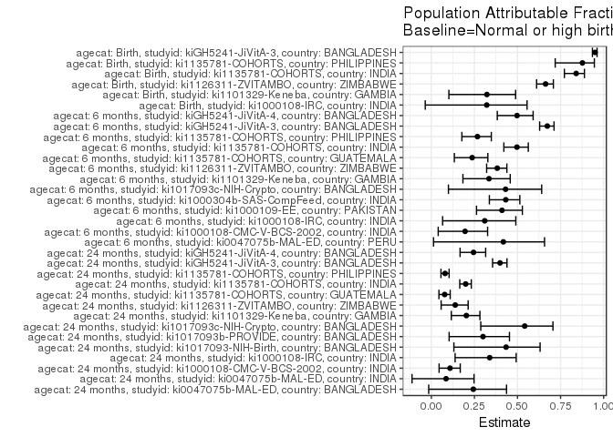

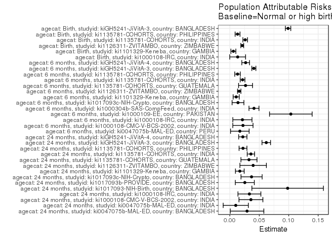

## Results Table

### Parameter: TSM

| agecat | studyid | country | intervention_level | baseline_level | estimate | ci_lower | ci_upper |
| --- | --- | --- | --- | --- | --- | --- | --- |
| Birth | ki1000108-IRC | INDIA | Normal or high birthweight | NA | 0.0281250 | 0.0099871 | 0.0462629 |
| Birth | ki1000108-IRC | INDIA | Low birth weight | NA | 0.1060606 | 0.0316782 | 0.1804431 |
| Birth | ki1101329-Keneba | GAMBIA | Normal or high birthweight | NA | 0.0127502 | 0.0068870 | 0.0186134 |
| Birth | ki1101329-Keneba | GAMBIA | Low birth weight | NA | 0.0694238 | 0.0280776 | 0.1107699 |
| Birth | ki1126311-ZVITAMBO | ZIMBABWE | Normal or high birthweight | NA | 0.0107473 | 0.0088996 | 0.0125950 |
| Birth | ki1126311-ZVITAMBO | ZIMBABWE | Low birth weight | NA | 0.1611635 | 0.1453373 | 0.1769897 |
| Birth | ki1135781-COHORTS | INDIA | Normal or high birthweight | NA | 0.0049514 | 0.0030565 | 0.0068462 |
| Birth | ki1135781-COHORTS | INDIA | Low birth weight | NA | 0.1314747 | 0.1137521 | 0.1491974 |
| Birth | ki1135781-COHORTS | PHILIPPINES | Normal or high birthweight | NA | 0.0018457 | 0.0002291 | 0.0034623 |
| Birth | ki1135781-COHORTS | PHILIPPINES | Low birth weight | NA | 0.1355932 | 0.0965193 | 0.1746672 |
| Birth | kiGH5241-JiVitA-3 | BANGLADESH | Normal or high birthweight | NA | 0.0051853 | 0.0037707 | 0.0065998 |
| Birth | kiGH5241-JiVitA-3 | BANGLADESH | Low birth weight | NA | 0.2344858 | 0.2248743 | 0.2440974 |
| 6 months | ki0047075b-MAL-ED | PERU | Normal or high birthweight | NA | 0.0237154 | 0.0049310 | 0.0424998 |
| 6 months | ki0047075b-MAL-ED | PERU | Low birth weight | NA | 0.2941176 | 0.0771195 | 0.5111158 |
| 6 months | ki1000108-CMC-V-BCS-2002 | INDIA | Normal or high birthweight | NA | 0.0915390 | 0.0602101 | 0.1228679 |
| 6 months | ki1000108-CMC-V-BCS-2002 | INDIA | Low birth weight | NA | 0.2895478 | 0.1531942 | 0.4259013 |
| 6 months | ki1000108-IRC | INDIA | Normal or high birthweight | NA | 0.0477244 | 0.0251437 | 0.0703051 |
| 6 months | ki1000108-IRC | INDIA | Low birth weight | NA | 0.1968317 | 0.1053709 | 0.2882925 |
| 6 months | ki1000109-EE | PAKISTAN | Normal or high birthweight | NA | 0.1491097 | 0.1045720 | 0.1936475 |
| 6 months | ki1000109-EE | PAKISTAN | Low birth weight | NA | 0.4013877 | 0.3219571 | 0.4808182 |
| 6 months | ki1000304b-SAS-CompFeed | INDIA | Normal or high birthweight | NA | 0.0539807 | 0.0378121 | 0.0701493 |
| 6 months | ki1000304b-SAS-CompFeed | INDIA | Low birth weight | NA | 0.2310503 | 0.2001021 | 0.2619985 |
| 6 months | ki1017093c-NIH-Crypto | BANGLADESH | Normal or high birthweight | NA | 0.0183118 | 0.0070463 | 0.0295773 |
| 6 months | ki1017093c-NIH-Crypto | BANGLADESH | Low birth weight | NA | 0.0765287 | 0.0373820 | 0.1156755 |
| 6 months | ki1101329-Keneba | GAMBIA | Normal or high birthweight | NA | 0.0216052 | 0.0144197 | 0.0287907 |
| 6 months | ki1101329-Keneba | GAMBIA | Low birth weight | NA | 0.1088998 | 0.0703127 | 0.1474868 |
| 6 months | ki1126311-ZVITAMBO | ZIMBABWE | Normal or high birthweight | NA | 0.0257085 | 0.0220544 | 0.0293627 |
| 6 months | ki1126311-ZVITAMBO | ZIMBABWE | Low birth weight | NA | 0.1550460 | 0.1338497 | 0.1762422 |
| 6 months | ki1135781-COHORTS | GUATEMALA | Normal or high birthweight | NA | 0.0861222 | 0.0653890 | 0.1068554 |
| 6 months | ki1135781-COHORTS | GUATEMALA | Low birth weight | NA | 0.3734380 | 0.2768291 | 0.4700468 |
| 6 months | ki1135781-COHORTS | INDIA | Normal or high birthweight | NA | 0.0219477 | 0.0179120 | 0.0259835 |
| 6 months | ki1135781-COHORTS | INDIA | Low birth weight | NA | 0.1285312 | 0.1110906 | 0.1459719 |
| 6 months | ki1135781-COHORTS | PHILIPPINES | Normal or high birthweight | NA | 0.0359920 | 0.0285728 | 0.0434112 |
| 6 months | ki1135781-COHORTS | PHILIPPINES | Low birth weight | NA | 0.1717037 | 0.1299191 | 0.2134883 |
| 6 months | kiGH5241-JiVitA-3 | BANGLADESH | Normal or high birthweight | NA | 0.0198298 | 0.0169164 | 0.0227433 |
| 6 months | kiGH5241-JiVitA-3 | BANGLADESH | Low birth weight | NA | 0.1341577 | 0.1255254 | 0.1427899 |
| 6 months | kiGH5241-JiVitA-4 | BANGLADESH | Normal or high birthweight | NA | 0.0272049 | 0.0197632 | 0.0346465 |
| 6 months | kiGH5241-JiVitA-4 | BANGLADESH | Low birth weight | NA | 0.1328972 | 0.1094904 | 0.1563040 |
| 24 months | ki0047075b-MAL-ED | BANGLADESH | Normal or high birthweight | NA | 0.0909274 | 0.0472528 | 0.1346019 |
| 24 months | ki0047075b-MAL-ED | BANGLADESH | Low birth weight | NA | 0.2666670 | 0.1487812 | 0.3845528 |
| 24 months | ki0047075b-MAL-ED | INDIA | Normal or high birthweight | NA | 0.1081081 | 0.0632608 | 0.1529555 |
| 24 months | ki0047075b-MAL-ED | INDIA | Low birth weight | NA | 0.1714286 | 0.0462846 | 0.2965725 |
| 24 months | ki1000108-CMC-V-BCS-2002 | INDIA | Normal or high birthweight | NA | 0.2948180 | 0.2455360 | 0.3441001 |
| 24 months | ki1000108-CMC-V-BCS-2002 | INDIA | Low birth weight | NA | 0.6081516 | 0.4673371 | 0.7489660 |
| 24 months | ki1000108-IRC | INDIA | Normal or high birthweight | NA | 0.0650244 | 0.0387714 | 0.0912773 |
| 24 months | ki1000108-IRC | INDIA | Low birth weight | NA | 0.2626459 | 0.1575730 | 0.3677188 |
| 24 months | ki1017093-NIH-Birth | BANGLADESH | Normal or high birthweight | NA | 0.1281344 | 0.0578073 | 0.1984615 |
| 24 months | ki1017093-NIH-Birth | BANGLADESH | Low birth weight | NA | 0.3960671 | 0.2715034 | 0.5206308 |
| 24 months | ki1017093b-PROVIDE | BANGLADESH | Normal or high birthweight | NA | 0.0594628 | 0.0375560 | 0.0813697 |
| 24 months | ki1017093b-PROVIDE | BANGLADESH | Low birth weight | NA | 0.1610651 | 0.1026171 | 0.2195131 |
| 24 months | ki1017093c-NIH-Crypto | BANGLADESH | Normal or high birthweight | NA | 0.0311965 | 0.0139639 | 0.0484290 |
| 24 months | ki1017093c-NIH-Crypto | BANGLADESH | Low birth weight | NA | 0.1784371 | 0.1109599 | 0.2459143 |
| 24 months | ki1101329-Keneba | GAMBIA | Normal or high birthweight | NA | 0.0665975 | 0.0530692 | 0.0801257 |
| 24 months | ki1101329-Keneba | GAMBIA | Low birth weight | NA | 0.2854273 | 0.2290927 | 0.3417619 |
| 24 months | ki1126311-ZVITAMBO | ZIMBABWE | Normal or high birthweight | NA | 0.2460914 | 0.2019220 | 0.2902608 |
| 24 months | ki1126311-ZVITAMBO | ZIMBABWE | Low birth weight | NA | 0.4737949 | 0.3842182 | 0.5633717 |
| 24 months | ki1135781-COHORTS | GUATEMALA | Normal or high birthweight | NA | 0.3886133 | 0.3493327 | 0.4278940 |
| 24 months | ki1135781-COHORTS | GUATEMALA | Low birth weight | NA | 0.7140895 | 0.6026672 | 0.8255117 |
| 24 months | ki1135781-COHORTS | INDIA | Normal or high birthweight | NA | 0.1441763 | 0.1333285 | 0.1550241 |
| 24 months | ki1135781-COHORTS | INDIA | Low birth weight | NA | 0.3263210 | 0.2986758 | 0.3539662 |
| 24 months | ki1135781-COHORTS | PHILIPPINES | Normal or high birthweight | NA | 0.2581828 | 0.2399100 | 0.2764557 |
| 24 months | ki1135781-COHORTS | PHILIPPINES | Low birth weight | NA | 0.4545278 | 0.3993655 | 0.5096901 |
| 24 months | kiGH5241-JiVitA-3 | BANGLADESH | Normal or high birthweight | NA | 0.0934201 | 0.0848758 | 0.1019645 |
| 24 months | kiGH5241-JiVitA-3 | BANGLADESH | Low birth weight | NA | 0.2598899 | 0.2438171 | 0.2759627 |
| 24 months | kiGH5241-JiVitA-4 | BANGLADESH | Normal or high birthweight | NA | 0.0681533 | 0.0576292 | 0.0786773 |
| 24 months | kiGH5241-JiVitA-4 | BANGLADESH | Low birth weight | NA | 0.1531603 | 0.1292312 | 0.1770893 |

### Parameter: E(Y)

| agecat | studyid | country | intervention_level | baseline_level | estimate | ci_lower | ci_upper |
| --- | --- | --- | --- | --- | --- | --- | --- |
| Birth | ki1000108-IRC | INDIA | NA | NA | 0.0414508 | 0.0215399 | 0.0613617 |
| Birth | ki1101329-Keneba | GAMBIA | NA | NA | 0.0188189 | 0.0120322 | 0.0256057 |
| Birth | ki1126311-ZVITAMBO | ZIMBABWE | NA | NA | 0.0318872 | 0.0289588 | 0.0348156 |
| Birth | ki1135781-COHORTS | INDIA | NA | NA | 0.0310334 | 0.0268616 | 0.0352053 |
| Birth | ki1135781-COHORTS | PHILIPPINES | NA | NA | 0.0149800 | 0.0106354 | 0.0193246 |
| Birth | kiGH5241-JiVitA-3 | BANGLADESH | NA | NA | 0.1040689 | 0.0993991 | 0.1087387 |
| 6 months | ki0047075b-MAL-ED | PERU | NA | NA | 0.0407407 | 0.0171167 | 0.0643648 |
| 6 months | ki1000108-CMC-V-BCS-2002 | INDIA | NA | NA | 0.1138211 | 0.0813725 | 0.1462698 |
| 6 months | ki1000108-IRC | INDIA | NA | NA | 0.0691358 | 0.0443985 | 0.0938731 |
| 6 months | ki1000109-EE | PAKISTAN | NA | NA | 0.2526882 | 0.2084696 | 0.2969067 |
| 6 months | ki1000304b-SAS-CompFeed | INDIA | NA | NA | 0.0950226 | 0.0765320 | 0.1135132 |
| 6 months | ki1017093c-NIH-Crypto | BANGLADESH | NA | NA | 0.0321678 | 0.0192256 | 0.0451101 |
| 6 months | ki1101329-Keneba | GAMBIA | NA | NA | 0.0324638 | 0.0240979 | 0.0408297 |
| 6 months | ki1126311-ZVITAMBO | ZIMBABWE | NA | NA | 0.0416213 | 0.0373152 | 0.0459273 |
| 6 months | ki1135781-COHORTS | GUATEMALA | NA | NA | 0.1128405 | 0.0904926 | 0.1351883 |
| 6 months | ki1135781-COHORTS | INDIA | NA | NA | 0.0436033 | 0.0385446 | 0.0486620 |
| 6 months | ki1135781-COHORTS | PHILIPPINES | NA | NA | 0.0491373 | 0.0409307 | 0.0573439 |
| 6 months | kiGH5241-JiVitA-3 | BANGLADESH | NA | NA | 0.0606368 | 0.0567889 | 0.0644847 |
| 6 months | kiGH5241-JiVitA-4 | BANGLADESH | NA | NA | 0.0541109 | 0.0456917 | 0.0625302 |
| 24 months | ki0047075b-MAL-ED | BANGLADESH | NA | NA | 0.1201923 | 0.0758932 | 0.1644914 |
| 24 months | ki0047075b-MAL-ED | INDIA | NA | NA | 0.1181818 | 0.0754264 | 0.1609372 |
| 24 months | ki1000108-CMC-V-BCS-2002 | INDIA | NA | NA | 0.3306452 | 0.2827744 | 0.3785159 |
| 24 months | ki1000108-IRC | INDIA | NA | NA | 0.0982801 | 0.0693231 | 0.1272371 |
| 24 months | ki1017093-NIH-Birth | BANGLADESH | NA | NA | 0.2262774 | 0.1559553 | 0.2965995 |
| 24 months | ki1017093b-PROVIDE | BANGLADESH | NA | NA | 0.0849220 | 0.0621566 | 0.1076874 |
| 24 months | ki1017093c-NIH-Crypto | BANGLADESH | NA | NA | 0.0680934 | 0.0462948 | 0.0898920 |
| 24 months | ki1101329-Keneba | GAMBIA | NA | NA | 0.0835655 | 0.0692473 | 0.0978836 |
| 24 months | ki1126311-ZVITAMBO | ZIMBABWE | NA | NA | 0.2857143 | 0.2441594 | 0.3272692 |
| 24 months | ki1135781-COHORTS | GUATEMALA | NA | NA | 0.4211332 | 0.3832346 | 0.4590318 |
| 24 months | ki1135781-COHORTS | INDIA | NA | NA | 0.1800041 | 0.1692028 | 0.1908054 |
| 24 months | ki1135781-COHORTS | PHILIPPINES | NA | NA | 0.2805486 | 0.2625932 | 0.2985040 |
| 24 months | kiGH5241-JiVitA-3 | BANGLADESH | NA | NA | 0.1553341 | 0.1465480 | 0.1641203 |
| 24 months | kiGH5241-JiVitA-4 | BANGLADESH | NA | NA | 0.0902171 | 0.0800344 | 0.1003999 |

### Parameter: RR

| agecat | studyid | country | intervention_level | baseline_level | estimate | ci_lower | ci_upper |
| --- | --- | --- | --- | --- | --- | --- | --- |
| Birth | ki1000108-IRC | INDIA | Normal or high birthweight | Normal or high birthweight | 1.000000 | 1.0000000 | 1.000000 |
| Birth | ki1000108-IRC | INDIA | Low birth weight | Normal or high birthweight | 3.771044 | 1.4543975 | 9.777775 |
| Birth | ki1101329-Keneba | GAMBIA | Normal or high birthweight | Normal or high birthweight | 1.000000 | 1.0000000 | 1.000000 |
| Birth | ki1101329-Keneba | GAMBIA | Low birth weight | Normal or high birthweight | 5.444909 | 2.5651095 | 11.557805 |
| Birth | ki1126311-ZVITAMBO | ZIMBABWE | Normal or high birthweight | Normal or high birthweight | 1.000000 | 1.0000000 | 1.000000 |
| Birth | ki1126311-ZVITAMBO | ZIMBABWE | Low birth weight | Normal or high birthweight | 14.995701 | 12.3027414 | 18.278126 |
| Birth | ki1135781-COHORTS | INDIA | Normal or high birthweight | Normal or high birthweight | 1.000000 | 1.0000000 | 1.000000 |
| Birth | ki1135781-COHORTS | INDIA | Low birth weight | Normal or high birthweight | 26.553250 | 17.6981262 | 39.838967 |
| Birth | ki1135781-COHORTS | PHILIPPINES | Normal or high birthweight | Normal or high birthweight | 1.000000 | 1.0000000 | 1.000000 |
| Birth | ki1135781-COHORTS | PHILIPPINES | Low birth weight | Normal or high birthweight | 73.464407 | 29.2170860 | 184.721332 |
| Birth | kiGH5241-JiVitA-3 | BANGLADESH | Normal or high birthweight | Normal or high birthweight | 1.000000 | 1.0000000 | 1.000000 |
| Birth | kiGH5241-JiVitA-3 | BANGLADESH | Low birth weight | Normal or high birthweight | 45.221423 | 34.3895369 | 59.465096 |
| 6 months | ki0047075b-MAL-ED | PERU | Normal or high birthweight | Normal or high birthweight | 1.000000 | 1.0000000 | 1.000000 |
| 6 months | ki0047075b-MAL-ED | PERU | Low birth weight | Normal or high birthweight | 12.401961 | 4.2012963 | 36.609803 |
| 6 months | ki1000108-CMC-V-BCS-2002 | INDIA | Normal or high birthweight | Normal or high birthweight | 1.000000 | 1.0000000 | 1.000000 |
| 6 months | ki1000108-CMC-V-BCS-2002 | INDIA | Low birth weight | Normal or high birthweight | 3.163109 | 1.7676414 | 5.660229 |
| 6 months | ki1000108-IRC | INDIA | Normal or high birthweight | Normal or high birthweight | 1.000000 | 1.0000000 | 1.000000 |
| 6 months | ki1000108-IRC | INDIA | Low birth weight | Normal or high birthweight | 4.124345 | 2.1256919 | 8.002205 |
| 6 months | ki1000109-EE | PAKISTAN | Normal or high birthweight | Normal or high birthweight | 1.000000 | 1.0000000 | 1.000000 |
| 6 months | ki1000109-EE | PAKISTAN | Low birth weight | Normal or high birthweight | 2.691895 | 1.8827316 | 3.848821 |
| 6 months | ki1000304b-SAS-CompFeed | INDIA | Normal or high birthweight | Normal or high birthweight | 1.000000 | 1.0000000 | 1.000000 |
| 6 months | ki1000304b-SAS-CompFeed | INDIA | Low birth weight | Normal or high birthweight | 4.280238 | 3.1772538 | 5.766124 |
| 6 months | ki1017093c-NIH-Crypto | BANGLADESH | Normal or high birthweight | Normal or high birthweight | 1.000000 | 1.0000000 | 1.000000 |
| 6 months | ki1017093c-NIH-Crypto | BANGLADESH | Low birth weight | Normal or high birthweight | 4.179213 | 1.8807684 | 9.286535 |
| 6 months | ki1101329-Keneba | GAMBIA | Normal or high birthweight | Normal or high birthweight | 1.000000 | 1.0000000 | 1.000000 |
| 6 months | ki1101329-Keneba | GAMBIA | Low birth weight | Normal or high birthweight | 5.040433 | 3.1075195 | 8.175642 |
| 6 months | ki1126311-ZVITAMBO | ZIMBABWE | Normal or high birthweight | Normal or high birthweight | 1.000000 | 1.0000000 | 1.000000 |
| 6 months | ki1126311-ZVITAMBO | ZIMBABWE | Low birth weight | Normal or high birthweight | 6.030921 | 4.9532850 | 7.343007 |
| 6 months | ki1135781-COHORTS | GUATEMALA | Normal or high birthweight | Normal or high birthweight | 1.000000 | 1.0000000 | 1.000000 |
| 6 months | ki1135781-COHORTS | GUATEMALA | Low birth weight | Normal or high birthweight | 4.336142 | 3.0475254 | 6.169637 |
| 6 months | ki1135781-COHORTS | INDIA | Normal or high birthweight | Normal or high birthweight | 1.000000 | 1.0000000 | 1.000000 |
| 6 months | ki1135781-COHORTS | INDIA | Low birth weight | Normal or high birthweight | 5.856238 | 4.6646689 | 7.352187 |
| 6 months | ki1135781-COHORTS | PHILIPPINES | Normal or high birthweight | Normal or high birthweight | 1.000000 | 1.0000000 | 1.000000 |
| 6 months | ki1135781-COHORTS | PHILIPPINES | Low birth weight | Normal or high birthweight | 4.770612 | 3.4698500 | 6.558998 |
| 6 months | kiGH5241-JiVitA-3 | BANGLADESH | Normal or high birthweight | Normal or high birthweight | 1.000000 | 1.0000000 | 1.000000 |
| 6 months | kiGH5241-JiVitA-3 | BANGLADESH | Low birth weight | Normal or high birthweight | 6.765442 | 5.7731035 | 7.928353 |
| 6 months | kiGH5241-JiVitA-4 | BANGLADESH | Normal or high birthweight | Normal or high birthweight | 1.000000 | 1.0000000 | 1.000000 |
| 6 months | kiGH5241-JiVitA-4 | BANGLADESH | Low birth weight | Normal or high birthweight | 4.885054 | 3.5290375 | 6.762115 |
| 24 months | ki0047075b-MAL-ED | BANGLADESH | Normal or high birthweight | Normal or high birthweight | 1.000000 | 1.0000000 | 1.000000 |
| 24 months | ki0047075b-MAL-ED | BANGLADESH | Low birth weight | Normal or high birthweight | 2.932748 | 1.5321128 | 5.613822 |
| 24 months | ki0047075b-MAL-ED | INDIA | Normal or high birthweight | Normal or high birthweight | 1.000000 | 1.0000000 | 1.000000 |
| 24 months | ki0047075b-MAL-ED | INDIA | Low birth weight | Normal or high birthweight | 1.585714 | 0.6848141 | 3.671784 |
| 24 months | ki1000108-CMC-V-BCS-2002 | INDIA | Normal or high birthweight | Normal or high birthweight | 1.000000 | 1.0000000 | 1.000000 |
| 24 months | ki1000108-CMC-V-BCS-2002 | INDIA | Low birth weight | Normal or high birthweight | 2.062803 | 1.5513420 | 2.742887 |
| 24 months | ki1000108-IRC | INDIA | Normal or high birthweight | Normal or high birthweight | 1.000000 | 1.0000000 | 1.000000 |
| 24 months | ki1000108-IRC | INDIA | Low birth weight | Normal or high birthweight | 4.039192 | 2.2881342 | 7.130296 |
| 24 months | ki1017093-NIH-Birth | BANGLADESH | Normal or high birthweight | Normal or high birthweight | 1.000000 | 1.0000000 | 1.000000 |
| 24 months | ki1017093-NIH-Birth | BANGLADESH | Low birth weight | Normal or high birthweight | 3.091030 | 1.6479289 | 5.797862 |
| 24 months | ki1017093b-PROVIDE | BANGLADESH | Normal or high birthweight | Normal or high birthweight | 1.000000 | 1.0000000 | 1.000000 |
| 24 months | ki1017093b-PROVIDE | BANGLADESH | Low birth weight | Normal or high birthweight | 2.708670 | 1.6191455 | 4.531336 |
| 24 months | ki1017093c-NIH-Crypto | BANGLADESH | Normal or high birthweight | Normal or high birthweight | 1.000000 | 1.0000000 | 1.000000 |
| 24 months | ki1017093c-NIH-Crypto | BANGLADESH | Low birth weight | Normal or high birthweight | 5.719786 | 2.9309018 | 11.162420 |
| 24 months | ki1101329-Keneba | GAMBIA | Normal or high birthweight | Normal or high birthweight | 1.000000 | 1.0000000 | 1.000000 |
| 24 months | ki1101329-Keneba | GAMBIA | Low birth weight | Normal or high birthweight | 4.285859 | 3.2323174 | 5.682793 |
| 24 months | ki1126311-ZVITAMBO | ZIMBABWE | Normal or high birthweight | Normal or high birthweight | 1.000000 | 1.0000000 | 1.000000 |
| 24 months | ki1126311-ZVITAMBO | ZIMBABWE | Low birth weight | Normal or high birthweight | 1.925281 | 1.4919578 | 2.484457 |
| 24 months | ki1135781-COHORTS | GUATEMALA | Normal or high birthweight | Normal or high birthweight | 1.000000 | 1.0000000 | 1.000000 |
| 24 months | ki1135781-COHORTS | GUATEMALA | Low birth weight | Normal or high birthweight | 1.837532 | 1.5257654 | 2.213003 |
| 24 months | ki1135781-COHORTS | INDIA | Normal or high birthweight | Normal or high birthweight | 1.000000 | 1.0000000 | 1.000000 |
| 24 months | ki1135781-COHORTS | INDIA | Low birth weight | Normal or high birthweight | 2.263346 | 2.0245809 | 2.530270 |
| 24 months | ki1135781-COHORTS | PHILIPPINES | Normal or high birthweight | Normal or high birthweight | 1.000000 | 1.0000000 | 1.000000 |
| 24 months | ki1135781-COHORTS | PHILIPPINES | Low birth weight | Normal or high birthweight | 1.760488 | 1.5314325 | 2.023804 |
| 24 months | kiGH5241-JiVitA-3 | BANGLADESH | Normal or high birthweight | Normal or high birthweight | 1.000000 | 1.0000000 | 1.000000 |
| 24 months | kiGH5241-JiVitA-3 | BANGLADESH | Low birth weight | Normal or high birthweight | 2.781948 | 2.4963940 | 3.100165 |
| 24 months | kiGH5241-JiVitA-4 | BANGLADESH | Normal or high birthweight | Normal or high birthweight | 1.000000 | 1.0000000 | 1.000000 |
| 24 months | kiGH5241-JiVitA-4 | BANGLADESH | Low birth weight | Normal or high birthweight | 2.247292 | 1.8052190 | 2.797622 |

### Parameter: PAR

| agecat | studyid | country | intervention_level | baseline_level | estimate | ci_lower | ci_upper |
| --- | --- | --- | --- | --- | --- | --- | --- |
| Birth | ki1000108-IRC | INDIA | Normal or high birthweight | NA | 0.0133258 | -0.0000892 | 0.0267408 |
| Birth | ki1101329-Keneba | GAMBIA | Normal or high birthweight | NA | 0.0060687 | 0.0018758 | 0.0102617 |
| Birth | ki1126311-ZVITAMBO | ZIMBABWE | Normal or high birthweight | NA | 0.0211399 | 0.0186761 | 0.0236036 |
| Birth | ki1135781-COHORTS | INDIA | Normal or high birthweight | NA | 0.0260821 | 0.0221706 | 0.0299936 |
| Birth | ki1135781-COHORTS | PHILIPPINES | Normal or high birthweight | NA | 0.0131343 | 0.0090385 | 0.0172301 |
| Birth | kiGH5241-JiVitA-3 | BANGLADESH | Normal or high birthweight | NA | 0.0988837 | 0.0942819 | 0.1034854 |
| 6 months | ki0047075b-MAL-ED | PERU | Normal or high birthweight | NA | 0.0170253 | 0.0012242 | 0.0328265 |
| 6 months | ki1000108-CMC-V-BCS-2002 | INDIA | Normal or high birthweight | NA | 0.0222821 | 0.0051138 | 0.0394505 |
| 6 months | ki1000108-IRC | INDIA | Normal or high birthweight | NA | 0.0214114 | 0.0051647 | 0.0376582 |
| 6 months | ki1000109-EE | PAKISTAN | Normal or high birthweight | NA | 0.1035784 | 0.0674329 | 0.1397240 |
| 6 months | ki1000304b-SAS-CompFeed | INDIA | Normal or high birthweight | NA | 0.0410419 | 0.0325365 | 0.0495474 |
| 6 months | ki1017093c-NIH-Crypto | BANGLADESH | Normal or high birthweight | NA | 0.0138561 | 0.0038428 | 0.0238693 |
| 6 months | ki1101329-Keneba | GAMBIA | Normal or high birthweight | NA | 0.0108585 | 0.0056735 | 0.0160435 |
| 6 months | ki1126311-ZVITAMBO | ZIMBABWE | Normal or high birthweight | NA | 0.0159128 | 0.0130049 | 0.0188206 |
| 6 months | ki1135781-COHORTS | GUATEMALA | Normal or high birthweight | NA | 0.0267183 | 0.0148144 | 0.0386222 |
| 6 months | ki1135781-COHORTS | INDIA | Normal or high birthweight | NA | 0.0216555 | 0.0177189 | 0.0255922 |
| 6 months | ki1135781-COHORTS | PHILIPPINES | Normal or high birthweight | NA | 0.0131453 | 0.0084724 | 0.0178182 |
| 6 months | kiGH5241-JiVitA-3 | BANGLADESH | Normal or high birthweight | NA | 0.0408070 | 0.0373451 | 0.0442689 |
| 6 months | kiGH5241-JiVitA-4 | BANGLADESH | Normal or high birthweight | NA | 0.0269061 | 0.0203796 | 0.0334325 |
| 24 months | ki0047075b-MAL-ED | BANGLADESH | Normal or high birthweight | NA | 0.0292649 | 0.0007909 | 0.0577390 |
| 24 months | ki0047075b-MAL-ED | INDIA | Normal or high birthweight | NA | 0.0100737 | -0.0112967 | 0.0314441 |
| 24 months | ki1000108-CMC-V-BCS-2002 | INDIA | Normal or high birthweight | NA | 0.0358271 | 0.0154947 | 0.0561595 |
| 24 months | ki1000108-IRC | INDIA | Normal or high birthweight | NA | 0.0332557 | 0.0137835 | 0.0527280 |
| 24 months | ki1017093-NIH-Birth | BANGLADESH | Normal or high birthweight | NA | 0.0981430 | 0.0374713 | 0.1588147 |
| 24 months | ki1017093b-PROVIDE | BANGLADESH | Normal or high birthweight | NA | 0.0254592 | 0.0093629 | 0.0415555 |
| 24 months | ki1017093c-NIH-Crypto | BANGLADESH | Normal or high birthweight | NA | 0.0368969 | 0.0189372 | 0.0548567 |
| 24 months | ki1101329-Keneba | GAMBIA | Normal or high birthweight | NA | 0.0169680 | 0.0095329 | 0.0244031 |
| 24 months | ki1126311-ZVITAMBO | ZIMBABWE | Normal or high birthweight | NA | 0.0396229 | 0.0171230 | 0.0621229 |
| 24 months | ki1135781-COHORTS | GUATEMALA | Normal or high birthweight | NA | 0.0325199 | 0.0188420 | 0.0461977 |
| 24 months | ki1135781-COHORTS | INDIA | Normal or high birthweight | NA | 0.0358278 | 0.0295551 | 0.0421005 |
| 24 months | ki1135781-COHORTS | PHILIPPINES | Normal or high birthweight | NA | 0.0223658 | 0.0157146 | 0.0290170 |
| 24 months | kiGH5241-JiVitA-3 | BANGLADESH | Normal or high birthweight | NA | 0.0619140 | 0.0546774 | 0.0691506 |
| 24 months | kiGH5241-JiVitA-4 | BANGLADESH | Normal or high birthweight | NA | 0.0220639 | 0.0150811 | 0.0290466 |

### Parameter: PAF

| agecat | studyid | country | intervention_level | baseline_level | estimate | ci_lower | ci_upper |
| --- | --- | --- | --- | --- | --- | --- | --- |
| Birth | ki1000108-IRC | INDIA | Normal or high birthweight | NA | 0.3214844 | -0.0355573 | 0.5554244 |
| Birth | ki1101329-Keneba | GAMBIA | Normal or high birthweight | NA | 0.3224799 | 0.1017009 | 0.4889971 |
| Birth | ki1126311-ZVITAMBO | ZIMBABWE | Normal or high birthweight | NA | 0.6629584 | 0.6107791 | 0.7081425 |
| Birth | ki1135781-COHORTS | INDIA | Normal or high birthweight | NA | 0.8404508 | 0.7719960 | 0.8883530 |
| Birth | ki1135781-COHORTS | PHILIPPINES | Normal or high birthweight | NA | 0.8767893 | 0.7188230 | 0.9460095 |
| Birth | kiGH5241-JiVitA-3 | BANGLADESH | Normal or high birthweight | NA | 0.9501745 | 0.9348936 | 0.9618690 |
| 6 months | ki0047075b-MAL-ED | PERU | Normal or high birthweight | NA | 0.4178944 | 0.0126231 | 0.6568210 |
| 6 months | ki1000108-CMC-V-BCS-2002 | INDIA | Normal or high birthweight | NA | 0.1957646 | 0.0397473 | 0.3264329 |
| 6 months | ki1000108-IRC | INDIA | Normal or high birthweight | NA | 0.3097013 | 0.0652640 | 0.4902172 |
| 6 months | ki1000109-EE | PAKISTAN | Normal or high birthweight | NA | 0.4099062 | 0.2620841 | 0.5281160 |
| 6 months | ki1000304b-SAS-CompFeed | INDIA | Normal or high birthweight | NA | 0.4319174 | 0.3365917 | 0.5135456 |
| 6 months | ki1017093c-NIH-Crypto | BANGLADESH | Normal or high birthweight | NA | 0.4307431 | 0.0990827 | 0.6403073 |
| 6 months | ki1101329-Keneba | GAMBIA | Normal or high birthweight | NA | 0.3344816 | 0.1832079 | 0.4577386 |
| 6 months | ki1126311-ZVITAMBO | ZIMBABWE | Normal or high birthweight | NA | 0.3823231 | 0.3208516 | 0.4382307 |
| 6 months | ki1135781-COHORTS | GUATEMALA | Normal or high birthweight | NA | 0.2367794 | 0.1334028 | 0.3278241 |
| 6 months | ki1135781-COHORTS | INDIA | Normal or high birthweight | NA | 0.4966489 | 0.4207908 | 0.5625720 |
| 6 months | ki1135781-COHORTS | PHILIPPINES | Normal or high birthweight | NA | 0.2675223 | 0.1771806 | 0.3479450 |
| 6 months | kiGH5241-JiVitA-3 | BANGLADESH | Normal or high birthweight | NA | 0.6729736 | 0.6285742 | 0.7120656 |
| 6 months | kiGH5241-JiVitA-4 | BANGLADESH | Normal or high birthweight | NA | 0.4972394 | 0.3825889 | 0.5905997 |
| 24 months | ki0047075b-MAL-ED | BANGLADESH | Normal or high birthweight | NA | 0.2434844 | -0.0154333 | 0.4363826 |
| 24 months | ki0047075b-MAL-ED | INDIA | Normal or high birthweight | NA | 0.0852391 | -0.1122687 | 0.2476750 |
| 24 months | ki1000108-CMC-V-BCS-2002 | INDIA | Normal or high birthweight | NA | 0.1083552 | 0.0449340 | 0.1675648 |
| 24 months | ki1000108-IRC | INDIA | Normal or high birthweight | NA | 0.3383772 | 0.1378378 | 0.4922710 |
| 24 months | ki1017093-NIH-Birth | BANGLADESH | Normal or high birthweight | NA | 0.4337288 | 0.1307722 | 0.6310944 |
| 24 months | ki1017093b-PROVIDE | BANGLADESH | Normal or high birthweight | NA | 0.2997950 | 0.1032121 | 0.4532855 |
| 24 months | ki1017093c-NIH-Crypto | BANGLADESH | Normal or high birthweight | NA | 0.5418577 | 0.2867244 | 0.7057318 |
| 24 months | ki1101329-Keneba | GAMBIA | Normal or high birthweight | NA | 0.2030505 | 0.1156369 | 0.2818238 |
| 24 months | ki1126311-ZVITAMBO | ZIMBABWE | Normal or high birthweight | NA | 0.1386802 | 0.0567235 | 0.2135161 |
| 24 months | ki1135781-COHORTS | GUATEMALA | Normal or high birthweight | NA | 0.0772200 | 0.0439519 | 0.1093304 |
| 24 months | ki1135781-COHORTS | INDIA | Normal or high birthweight | NA | 0.1990387 | 0.1648405 | 0.2318366 |
| 24 months | ki1135781-COHORTS | PHILIPPINES | Normal or high birthweight | NA | 0.0797216 | 0.0558606 | 0.1029796 |
| 24 months | kiGH5241-JiVitA-3 | BANGLADESH | Normal or high birthweight | NA | 0.3985861 | 0.3553362 | 0.4389343 |
| 24 months | kiGH5241-JiVitA-4 | BANGLADESH | Normal or high birthweight | NA | 0.2445640 | 0.1666401 | 0.3152016 |